# Lathyrus ms2: selection on reaction norms for flowering time

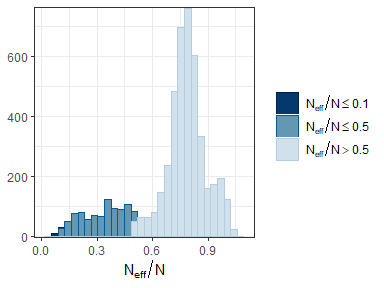

```r
mcmc_neff_hist(neff_ratio(bivar1.all.brm.nb))+theme_bw()
```

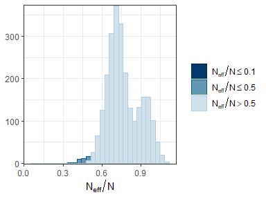

```r
mcmc_neff_hist(neff_ratio(bivar1.all.brm.zinb))+theme_bw()
```

Some (few) are < 0.1 - Do we need to worry about this?

Posterior predictive checks:

```r
y2_fitness<-round(subset(datadef,!is.na(FFD))$mean_fitness_fl)
y2_FFD<-subset(datadef,!is.na(FFD))$FFD # vectors of outcome values
yrep2_fitness_pois<-posterior_predict(bivar1.all.brm.pois,
                                 draws = 500,resp="roundmeanfitnessfl")
```

Each row of the matrix is a draw from the posterior predictive distribution, i.e. a vector with one element for each of the data points in y.

Comparison of the distribution of y and the distributions of the simulated datasets in the yrep matrix

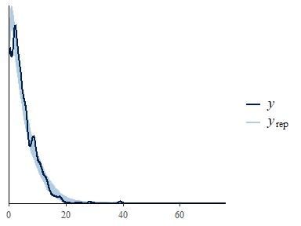

```r
ppc_dens_overlay(y2_fitness, yrep2_fitness_pois[1:500,])
```

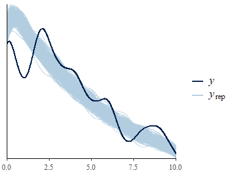

```r
ppc_dens_overlay(y2_fitness, yrep2_fitness_pois[1:500,])+xlim(0, 10)
```

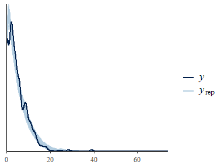

```r
ppc_dens_overlay(y2_fitness, yrep2_fitness_nb[1:500,])
```

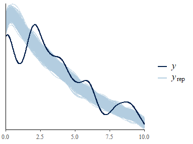

```r
ppc_dens_overlay(y2_fitness, yrep2_fitness_nb[1:500,])+xlim(0,10)
```

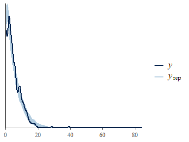

```r
ppc_dens_overlay(y2_fitness, yrep2_fitness_zinb[1:500,])
```

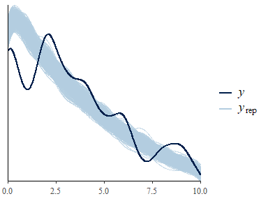

```r
ppc_dens_overlay(y2_fitness, yrep2_fitness_zinb[1:500,])+xlim(0,10)
```

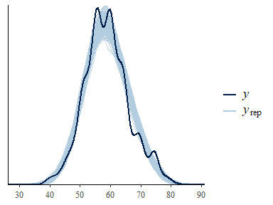

```r
ppc_dens_overlay(y2_FFD, yrep2_FFD_pois[1:500,])
```

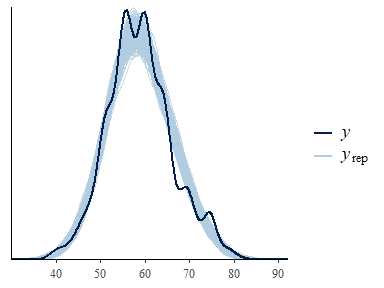

```r
ppc_dens_overlay(y2_FFD, yrep2_FFD_nb[1:500,])
```

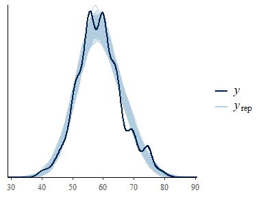

```r
ppc_dens_overlay(y2_FFD, yrep2_FFD_zinb[1:500,])
```

All look pretty similar.

Separate histograms of y and some of the yrep datasets

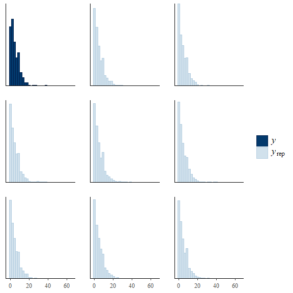

```r
ppc_hist(y2_fitness, yrep2_fitness_pois[1:8, ])
```

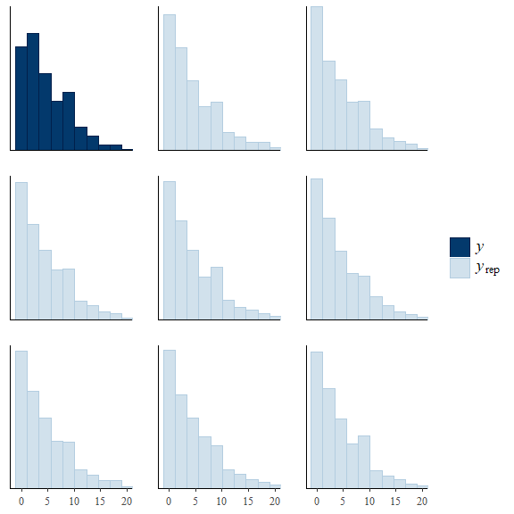

```r
ppc_hist(y2_fitness, yrep2_fitness_pois[1:8, ])+
  coord_cartesian(xlim = c(-1, 20))
```

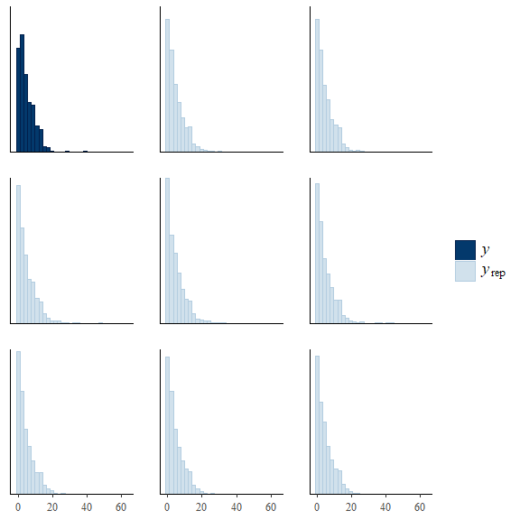

```r
ppc_hist(y2_fitness, yrep2_fitness_nb[1:8, ])
```

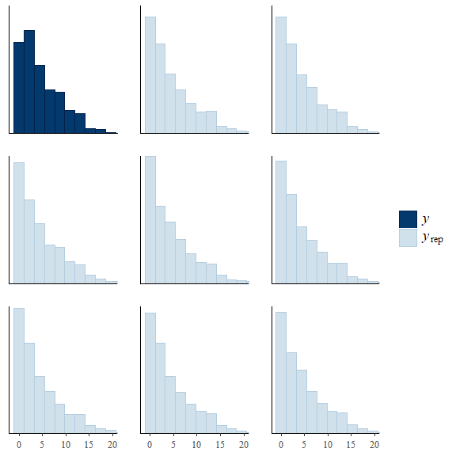

```r
ppc_hist(y2_fitness, yrep2_fitness_nb[1:8, ])+
  coord_cartesian(xlim = c(-1, 20))
```

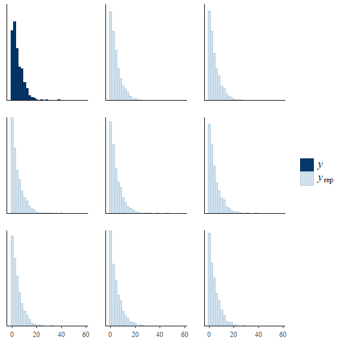

```r
ppc_hist(y2_fitness, yrep2_fitness_zinb[1:8, ])
```

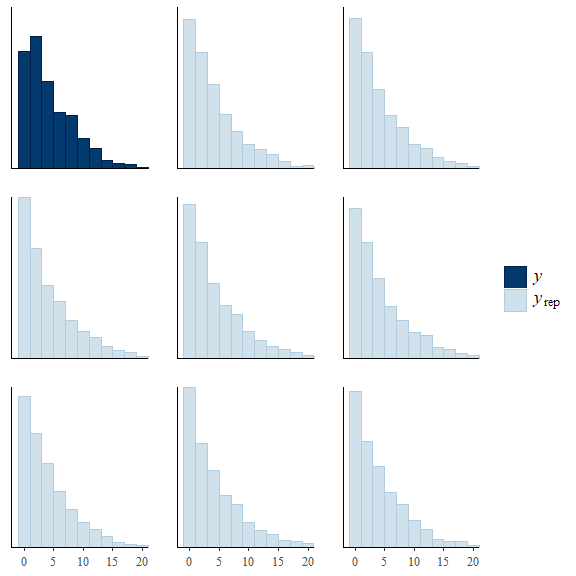

```r
ppc_hist(y2_fitness, yrep2_fitness_zinb[1:8, ])+
  coord_cartesian(xlim = c(-1, 20))
```

Here, negative binomial looks a bit better for fitness.

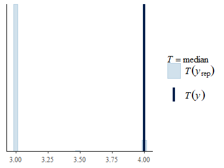

```r
ppc_stat(y2_fitness, yrep2_fitness_pois,stat="median")
```

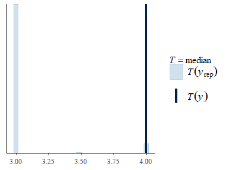

```r
ppc_stat(y2_fitness, yrep2_fitness_nb,stat="median")
```

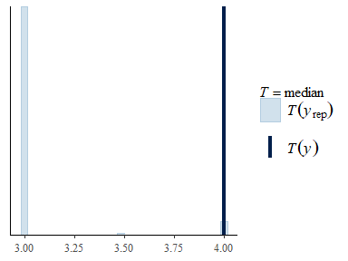

```r
ppc_stat(y2_fitness, yrep2_fitness_zinb,stat="median")
```

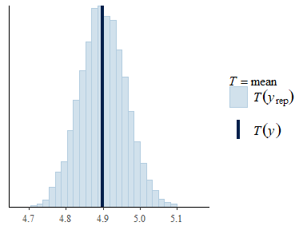

```r
ppc_stat(y2_fitness, yrep2_fitness_pois,stat="mean")
```

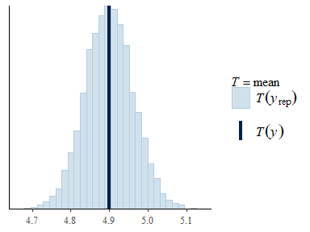

```r
ppc_stat(y2_fitness, yrep2_fitness_nb,stat="mean")
```

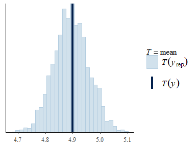

```r
ppc_stat(y2_fitness, yrep2_fitness_zinb,stat="mean")
```